# BANA 7042 PROJECT

Background: Flight landing

Motivation: To reduce the risk of landing overrun

Goal: To study what factors and how they would impact the landing distance of a commercial flight

Data: Landing data (landing distance and other parameters) from 950 commercial flights (not real data set but simulated from statistical models)

## Step1

```r
library("readxl")
FAA1 <- read_excel("C:/Users/Pooja Purohit/Documents/Assignments/Statistical Modelling/FAA1.xls")
```

```
## readxl works best with a newer version of the tibble package.
## You currently have tibble v1.4.2.
## Falling back to column name repair from tibble <= v1.4.2.
## Message displays once per session.
```

```r
FAA2 <- read_excel("C:/Users/Pooja Purohit/Documents/Assignments/Statistical Modelling/FAA2.xls")
```

## Step2

Looking at structure of both data, we can say that data set FAA1 has 800 observations of 8 varibales. Data set FAA2 has 150 observations of 7 variables. The ’duration variable is not available in dataset FAA2

```r
str(FAA1)
```

```
## Classes 'tbl_df', 'tbl' and 'data.frame':    800 obs. of  8 variables:
##  $ aircraft    : chr  "boeing" "boeing" "boeing" "boeing" ...
##  $ duration    : num  98.5 125.7 112 196.8 90.1 ...
##  $ no_pasg     : num  53 69 61 56 70 55 54 57 61 56 ...
##  $ speed_ground: num  107.9 101.7 71.1 85.8 59.9 ...
##  $ speed_air   : num  109 103 NA NA NA ...
##  $ height      : num  27.4 27.8 18.6 30.7 32.4 ...
##  $ pitch       : num  4.04 4.12 4.43 3.88 4.03 ...
##  $ distance    : num  3370 2988 1145 1664 1050 ...
```

```r
str(FAA2)
```

```
## Classes 'tbl_df', 'tbl' and 'data.frame':    150 obs. of  7 variables:
##  $ aircraft    : chr  "boeing" "boeing" "boeing" "boeing" ...
##  $ no_pasg     : num  53 69 61 56 70 55 54 57 61 56 ...
##  $ speed_ground: num  107.9 101.7 71.1 85.8 59.9 ...
##  $ speed_air   : num  109 103 NA NA NA ...
##  $ height      : num  27.4 27.8 18.6 30.7 32.4 ...
##  $ pitch       : num  4.04 4.12 4.43 3.88 4.03 ...
##  $ distance    : num  3370 2988 1145 1664 1050 ...
```

## Step3

In order to merge the datasets FAA1 and FAA2 , we need to create additional variable ‘duration’ in FAA2 and assign ‘NA’ to it.The merged datset contains 950 observations with 8 variables. Duplicate rows are checked using duplicated() function for only 7 variables since FAA2 had only 7 variables. 100 duplicate rows are found in the merged data. Dataset FAA_dist is created by removing all the duplicate rows.

```r
FAA2['duration']=NA
FAA_merge<- rbind(FAA1,FAA2)
str(FAA_merge)
```

```
## Classes 'tbl_df', 'tbl' and 'data.frame':    950 obs. of  8 variables:
##  $ aircraft    : chr  "boeing" "boeing" "boeing" "boeing" ...
##  $ duration    : num  98.5 125.7 112 196.8 90.1 ...
##  $ no_pasg     : num  53 69 61 56 70 55 54 57 61 56 ...
##  $ speed_ground: num  107.9 101.7 71.1 85.8 59.9 ...
##  $ speed_air   : num  109 103 NA NA NA ...
##  $ height      : num  27.4 27.8 18.6 30.7 32.4 ...
##  $ pitch       : num  4.04 4.12 4.43 3.88 4.03 ...
##  $ distance    : num  3370 2988 1145 1664 1050 ...
```

```r
#check duplicates
dup<-FAA_merge[duplicated(FAA_merge[,c(1,3,4,5,6,7,8)]),]
str(dup)
```

```
## Classes 'tbl_df', 'tbl' and 'data.frame':    100 obs. of  8 variables:
##  $ aircraft    : chr  "boeing" "boeing" "boeing" "boeing" ...
##  $ duration    : num  NA NA NA NA NA NA NA NA NA NA ...
##  $ no_pasg     : num  53 69 61 56 70 55 54 57 61 56 ...
##  $ speed_ground: num  107.9 101.7 71.1 85.8 59.9 ...
##  $ speed_air   : num  109 103 NA NA NA ...
##  $ height      : num  27.4 27.8 18.6 30.7 32.4 ...
##  $ pitch       : num  4.04 4.12 4.43 3.88 4.03 ...
##  $ distance    : num  3370 2988 1145 1664 1050 ...
```

```r
FAA_dist<-FAA_merge[!duplicated(FAA_merge[,c(1,3,4,5,6,7,8)]),]
```

## Step 4

The structure of cleaned dataset FAA_dist is examined. The sample size is 850 with 8 variables.

```r
str(FAA_dist)
```

```
## Classes 'tbl_df', 'tbl' and 'data.frame':    850 obs. of  8 variables:
##  $ aircraft    : chr  "boeing" "boeing" "boeing" "boeing" ...
##  $ duration    : num  98.5 125.7 112 196.8 90.1 ...
##  $ no_pasg     : num  53 69 61 56 70 55 54 57 61 56 ...
##  $ speed_ground: num  107.9 101.7 71.1 85.8 59.9 ...
##  $ speed_air   : num  109 103 NA NA NA ...
##  $ height      : num  27.4 27.8 18.6 30.7 32.4 ...
##  $ pitch       : num  4.04 4.12 4.43 3.88 4.03 ...
##  $ distance    : num  3370 2988 1145 1664 1050 ...
```

```r
summary(FAA_dist)
```

```
##    aircraft            duration         no_pasg      speed_ground
##  Length:850         Min.   : 14.76   Min.   :29.0   Min.   : 27.74
##  Class :character   1st Qu.:119.49   1st Qu.:55.0   1st Qu.: 65.90
##  Mode  :character   Median :153.95   Median :60.0   Median : 79.64
##                     Mean   :154.01   Mean   :60.1   Mean   : 79.45
##                     3rd Qu.:188.91   3rd Qu.:65.0   3rd Qu.: 92.06
##                     Max.   :305.62   Max.   :87.0   Max.   :141.22
##                     NA's   :50
##    speed_air          height           pitch          distance
##  Min.   : 90.00   Min.   :-3.546   Min.   :2.284   Min.   :  34.08
##  1st Qu.: 96.25   1st Qu.:23.314   1st Qu.:3.642   1st Qu.: 883.79
##  Median :101.15   Median :30.093   Median :4.008   Median :1258.09
##  Mean   :103.80   Mean   :30.144   Mean   :4.009   Mean   :1526.02
##  3rd Qu.:109.40   3rd Qu.:36.993   3rd Qu.:4.377   3rd Qu.:1936.95
##  Max.   :141.72   Max.   :59.946   Max.   :5.927   Max.   :6533.05
##  NA's   :642
```

## Step 5

The key observations from the summary statistics are: -The ‘speed_air’ column has 642 missing values -The ‘duration’ column has 50 missing values -The ‘height’ column has negative minimum value -The ‘distance’ column has very high maximum value signifying an outlier -The dataframe has 1 character value and 7 numeric values

## Step 6

Looking at the variable dictionary, below are some of the abnormal values: -The duration of normal flight is <40 min for some observations -The ground speed is <30 MPH and >140 MPH for some observations -The speed of air is >140 MPH for some observations -The height of aircraft is <6 meters for some observations -The landing distance is >6000 meters for some observations

After removing all these abnormal rows, we are left with 831 rows

```r
library(dplyr)
FAA_dist1<-filter(FAA_dist,(duration>40|is.na(duration))&
                  (speed_ground>=30|is.na(speed_ground)) &
                    (speed_air<=140| is.na(speed_air)) &
                    (height>=6 |is.na(height))&
                    (distance<=6000|is.na(distance)))
summary(FAA_dist1)
```

```
##    aircraft            duration         no_pasg       speed_ground
##  Length:831         Min.   : 41.95   Min.   :29.00   Min.   : 33.57
##  Class :character   1st Qu.:119.63   1st Qu.:55.00   1st Qu.: 66.20
##  Mode  :character   Median :154.28   Median :60.00   Median : 79.79
##                     Mean   :154.78   Mean   :60.06   Mean   : 79.54
##                     3rd Qu.:189.66   3rd Qu.:65.00   3rd Qu.: 91.91
##                     Max.   :305.62   Max.   :87.00   Max.   :132.78
##                     NA's   :50
##    speed_air          height           pitch          distance
##  Min.   : 90.00   Min.   : 6.228   Min.   :2.284   Min.   :  41.72
##  1st Qu.: 96.23   1st Qu.:23.530   1st Qu.:3.640   1st Qu.: 893.28
##  Median :101.12   Median :30.167   Median :4.001   Median :1262.15
##  Mean   :103.48   Mean   :30.458   Mean   :4.005   Mean   :1522.48
##  3rd Qu.:109.36   3rd Qu.:37.004   3rd Qu.:4.370   3rd Qu.:1936.63
##  Max.   :132.91   Max.   :59.946   Max.   :5.927   Max.   :5381.96
##  NA's   :628
```

## Step 7

Looking at the FAA_dist1 dataset, we can see that there are still missing values in duration and speed_air. The imputation of speed_air seems like a bad idea since the missing values are large. The missing values in duration are small and can be imputed using mean values for respective aircraft.

```r
FAA_dist1$duration[is.na(FAA_dist1$duration)&FAA_dist1$aircraft=='boeing']=mean(FAA_dist1[FAA_dist1$aircraft=='boeing',]$duration,na.rm=TRUE)
FAA_dist1$duration[is.na(FAA_dist1$duration)&FAA_dist1$aircraft=='airbus']=mean(FAA_dist1[FAA_dist1$aircraft=='airbus',]$duration,na.rm=TRUE)
summary(FAA_dist1)
```

```
##    aircraft            duration         no_pasg       speed_ground
##  Length:831         Min.   : 41.95   Min.   :29.00   Min.   : 33.57
##  Class :character   1st Qu.:122.67   1st Qu.:55.00   1st Qu.: 66.20
##  Mode  :character   Median :156.90   Median :60.00   Median : 79.79
##                     Mean   :154.90   Mean   :60.06   Mean   : 79.54
##                     3rd Qu.:186.37   3rd Qu.:65.00   3rd Qu.: 91.91
##                     Max.   :305.62   Max.   :87.00   Max.   :132.78
##
##    speed_air          height           pitch          distance
##  Min.   : 90.00   Min.   : 6.228   Min.   :2.284   Min.   :  41.72
##  1st Qu.: 96.23   1st Qu.:23.530   1st Qu.:3.640   1st Qu.: 893.28
##  Median :101.12   Median :30.167   Median :4.001   Median :1262.15
##  Mean   :103.48   Mean   :30.458   Mean   :4.005   Mean   :1522.48
##  3rd Qu.:109.36   3rd Qu.:37.004   3rd Qu.:4.370   3rd Qu.:1936.63
##  Max.   :132.91   Max.   :59.946   Max.   :5.927   Max.   :5381.96
##  NA's   :628
```

# Step 8

Below are the histogram for remaining set of variables

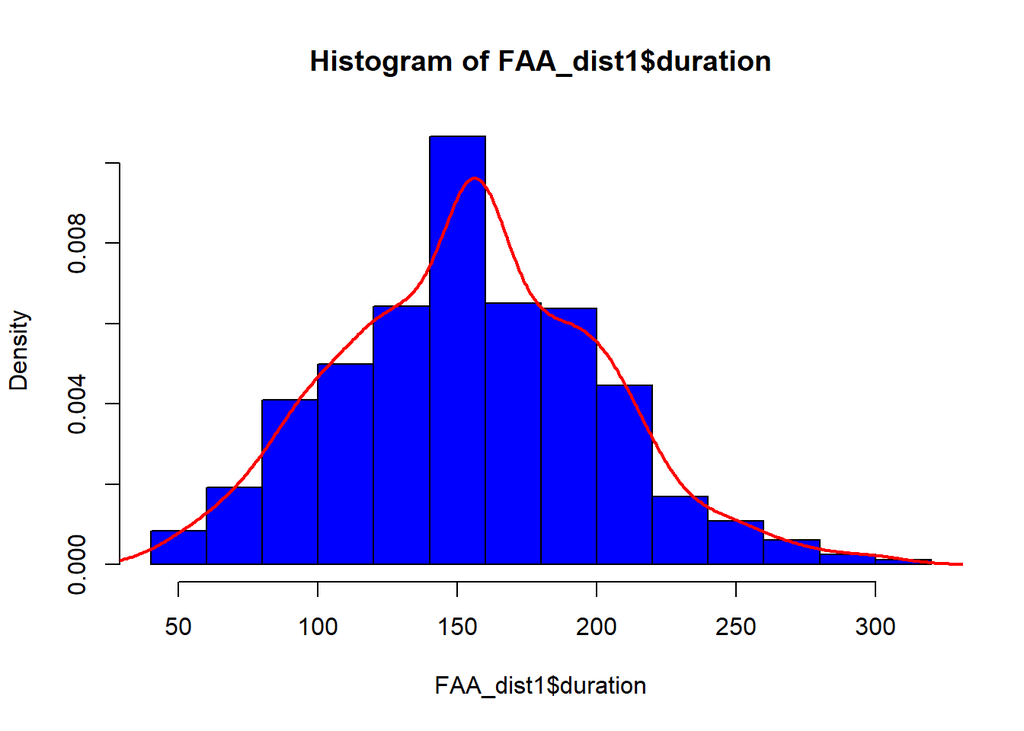

```r
hist(FAA_dist1$duration,col='blue',prob=T,breaks = 10)
lines(density(FAA_dist1$duration), col="red", lwd=2)
```

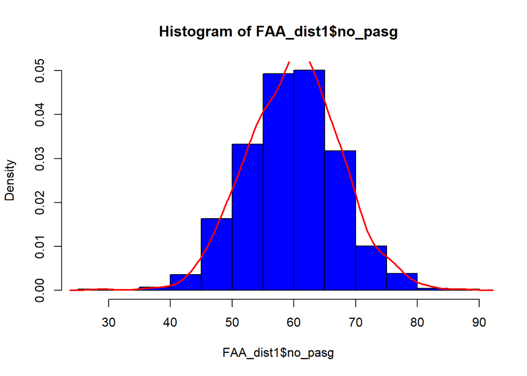

```r
hist(FAA_dist1$no_pasg,col='blue',prob=T,breaks=10)
lines(density(FAA_dist1$no_pasg), col="red", lwd=2)
```

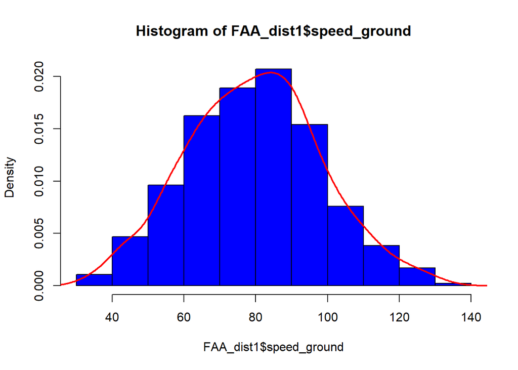

```r
hist(FAA_dist1$speed_ground,col='blue',prob=T,breaks = 10)
lines(density(FAA_dist1$speed_ground), col="red", lwd=2)
```

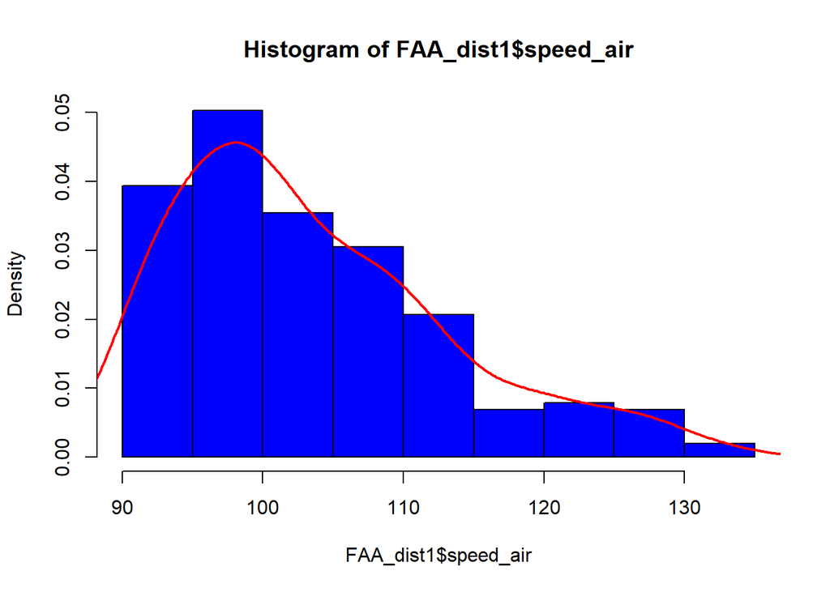

```r
hist(FAA_dist1$speed_air,col='blue',prob=T,breaks = 10)
lines(density(FAA_dist1$speed_air,na.rm = TRUE), col="red", lwd=2)
```

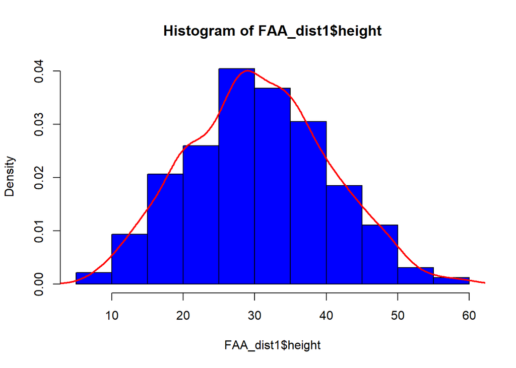

```r
hist(FAA_dist1$height,col='blue',prob=T,breaks = 10)
lines(density(FAA_dist1$height), col="red", lwd=2)
```

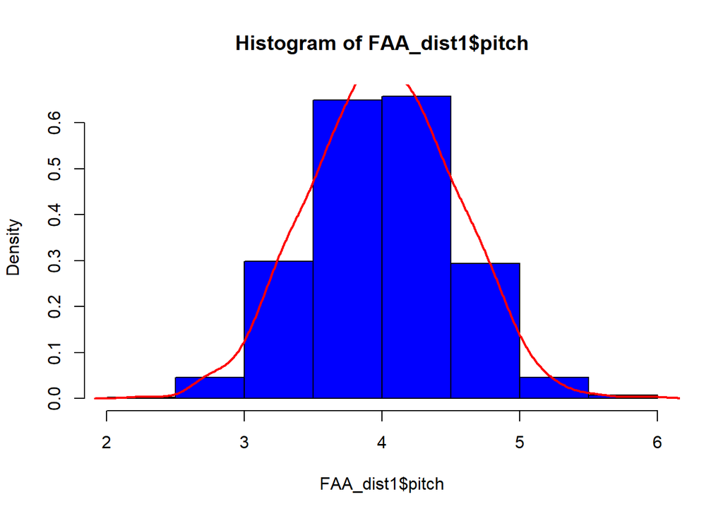

```r
hist(FAA_dist1$pitch,col='blue',prob=T,breaks = 10)
lines(density(FAA_dist1$pitch), col="red", lwd=2)
```

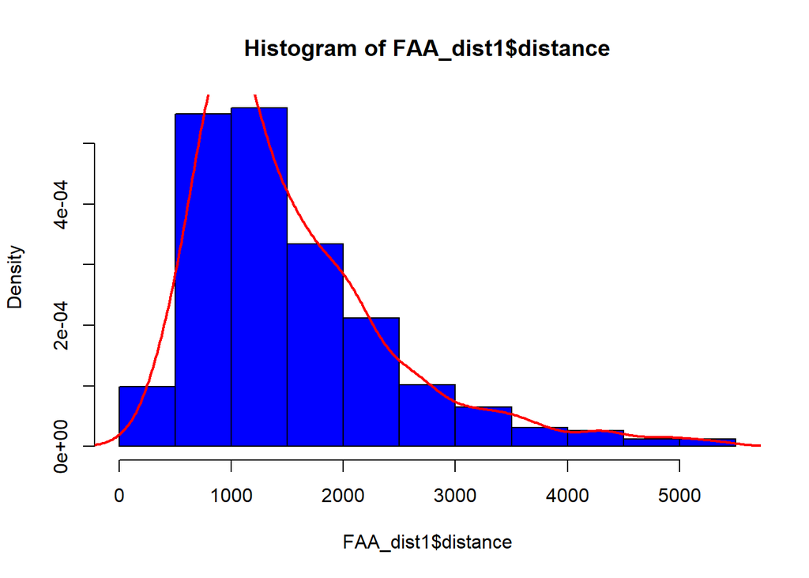

```r
hist(FAA_dist1$distance,col='blue',prob=T,breaks = 10)
lines(density(FAA_dist1$distance), col="red", lwd=2)
```

## Step 10

```r
round(cor(FAA_dist1[-1],use='pairwise.complete.obs'),2)
```

```
##              duration no_pasg speed_ground speed_air height pitch distance
## duration         1.00   -0.04        -0.05      0.04   0.01 -0.05    -0.05
## no_pasg         -0.04    1.00         0.00     -0.01   0.05 -0.02    -0.02
## speed_ground    -0.05    0.00         1.00      0.99  -0.06 -0.04     0.87
## speed_air        0.04   -0.01         0.99      1.00  -0.08 -0.04     0.94
## height           0.01    0.05        -0.06     -0.08   1.00  0.02     0.10
## pitch           -0.05   -0.02        -0.04     -0.04   0.02  1.00     0.09
## distance        -0.05   -0.02         0.87      0.94   0.10  0.09     1.00
```

# Step 11

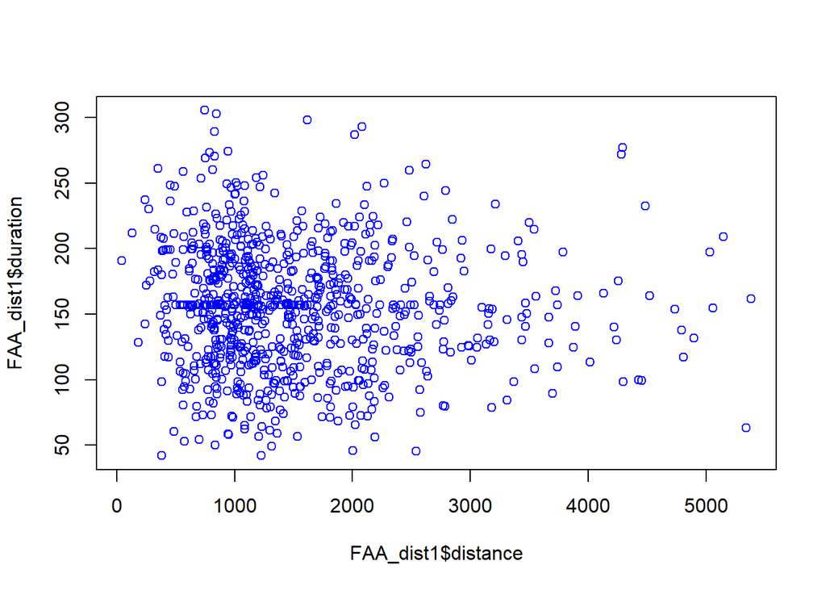

```r
plot(FAA_dist1$distance,FAA_dist1$duration,col='blue')
```

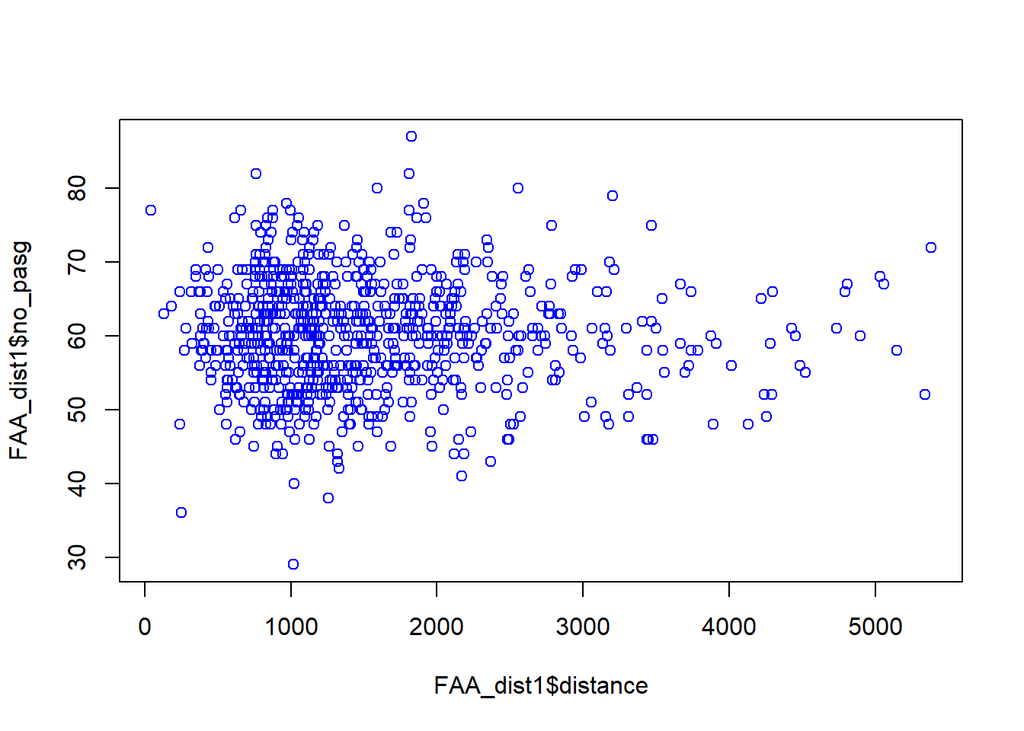

```r
plot(FAA_dist1$distance,FAA_dist1$no_pasg,col='blue')
```

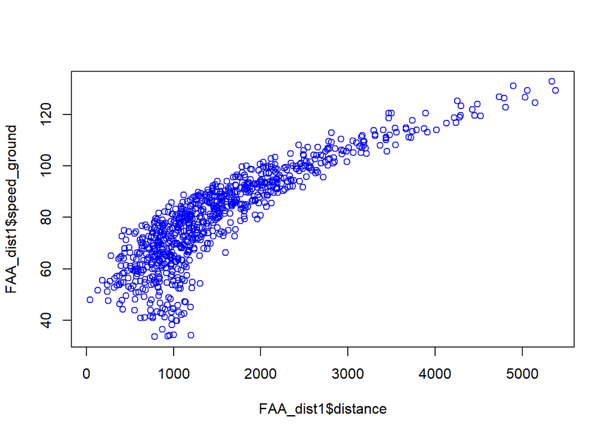

```r
plot(FAA_dist1$distance,FAA_dist1$speed_ground,col='blue')
```

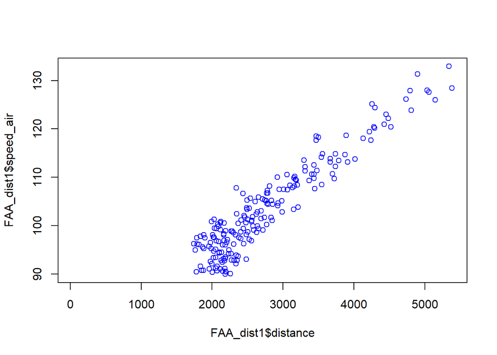

```r
plot(FAA_dist1$distance,FAA_dist1$speed_air,col='blue')
```

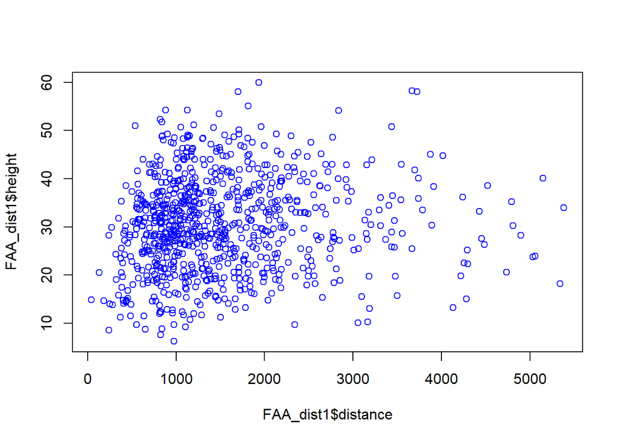

```r
plot(FAA_dist1$distance,FAA_dist1$height,col='blue')
```

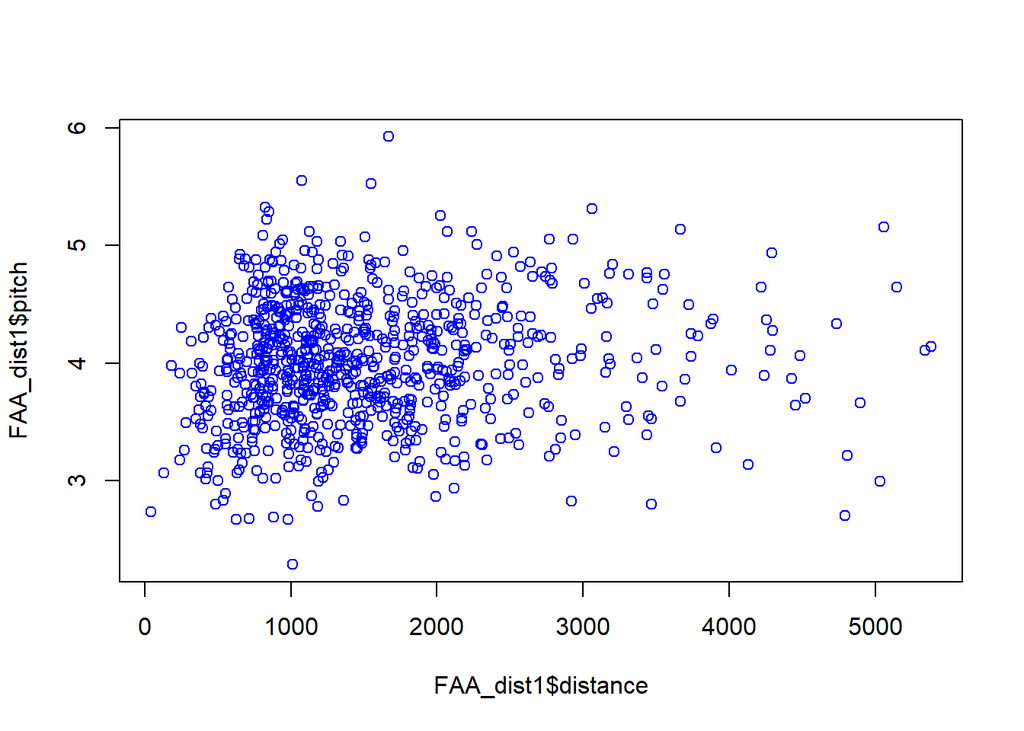

```r
plot(FAA_dist1$distance,FAA_dist1$pitch,col='blue')
```

The correlation strengths observed in Table 1 is consistent with the scatter plots

# Step12

```r
 FAA_dist1$aircraft[FAA_dist1$aircraft=='airbus']=1
 FAA_dist1$aircraft[FAA_dist1$aircraft=='boeing']=0
```

# Step13

```r
 attach(FAA_dist1)
 model1<- lm(distance~aircraft)
 summary(model1)

 model2<- lm(distance~duration)
 summary(model2)

 model3<- lm(distance~no_pasg)
 summary(model3)

 model4<- lm(distance~speed_air)
 summary(model4)

 model5<- lm(distance~speed_ground)
 summary(model5)

 model6<- lm(distance~height)
 summary(model6)

 model7<- lm(distance~pitch)
 summary(model7)
```

[output not shown]

# Step 14

```r
aircraft1<- as.numeric(aircraft)-0.5
 duration1<- (duration-mean(duration))/sd(duration)
 no_pasg1<- (no_pasg-mean(no_pasg))/sd(no_pasg)
 speed_air1<-(speed_air-mean(speed_air,na.rm=TRUE))/sd(speed_air,na.rm=TRUE)
 speed_ground1<-(speed_ground-mean(speed_ground))/sd(speed_ground)
 height1<-(height-mean(height))/sd(height)
 pitch1<- (pitch-mean(pitch))/sd(pitch)

 model1<- lm(distance~aircraft1)
 summary(model1)

 model2<- lm(distance~duration1)
 summary(model2)

 model3<- lm(distance~no_pasg1)
 summary(model3)

 model4<- lm(distance~speed_air1)
 summary(model4)

 model5<- lm(distance~speed_ground1)
 summary(model5)

 model6<- lm(distance~height1)
 summary(model6)

 model7<- lm(distance~pitch1)
 summary(model7)
```

[output not shown]

# Step 15

# Step 16

```r
model1<- lm(FAA_dist1$distance~FAA_dist1$speed_air)
 model2<- lm(FAA_dist1$distance~FAA_dist1$speed_ground)
 model3<- lm(FAA_dist1$distance~FAA_dist1$speed_air+FAA_dist1$speed_ground)
 summary(model1)
```

```
##
## Call:
## lm(formula = FAA_dist1$distance ~ FAA_dist1$speed_air)
##
## Residuals:
##     Min      1Q  Median      3Q     Max
## -776.21 -196.39    8.72  209.17  624.34
##
## Coefficients:
##                      Estimate Std. Error t value Pr(>|t|)
## (Intercept)         -5455.709    207.547  -26.29   <2e-16 ***
## FAA_dist1$speed_air    79.532      1.997   39.83   <2e-16 ***
## ---
## Signif. codes:  0 '***' 0.001 '**' 0.01 '*' 0.05 '.' 0.1 ' ' 1
##
## Residual standard error: 276.3 on 201 degrees of freedom
##   (628 observations deleted due to missingness)
## Multiple R-squared:  0.8875, Adjusted R-squared:  0.887
## F-statistic:  1586 on 1 and 201 DF,  p-value: < 2.2e-16
```

```r
 summary(model2)
```

```
##
## Call:
## lm(formula = FAA_dist1$distance ~ FAA_dist1$speed_ground)
##
## Residuals:
##     Min      1Q  Median      3Q     Max
## -897.09 -319.16  -72.09  210.83 1798.88
##
## Coefficients:
##                          Estimate Std. Error t value Pr(>|t|)
## (Intercept)            -1773.9407    67.8388  -26.15   <2e-16 ***
## FAA_dist1$speed_ground    41.4422     0.8302   49.92   <2e-16 ***
## ---
## Signif. codes:  0 '***' 0.001 '**' 0.01 '*' 0.05 '.' 0.1 ' ' 1
##
## Residual standard error: 448.1 on 829 degrees of freedom
## Multiple R-squared:  0.7504, Adjusted R-squared:  0.7501
## F-statistic:  2492 on 1 and 829 DF,  p-value: < 2.2e-16
```

```r
 summary(model3)
```

```
##
## Call:
## lm(formula = FAA_dist1$distance ~ FAA_dist1$speed_air + FAA_dist1$speed_ground)
##
## Residuals:
##     Min      1Q  Median      3Q     Max
## -819.74 -202.02    3.52  211.25  636.25
##
## Coefficients:
##                        Estimate Std. Error t value Pr(>|t|)
## (Intercept)            -5462.28     207.48 -26.327  < 2e-16 ***
## FAA_dist1$speed_air       93.96      12.89   7.291 6.99e-12 ***
## FAA_dist1$speed_ground   -14.37      12.68  -1.133    0.258
## ---
## Signif. codes:  0 '***' 0.001 '**' 0.01 '*' 0.05 '.' 0.1 ' ' 1
##
## Residual standard error: 276.1 on 200 degrees of freedom
##   (628 observations deleted due to missingness)
## Multiple R-squared:  0.8883, Adjusted R-squared:  0.8871
## F-statistic:   795 on 2 and 200 DF,  p-value: < 2.2e-16
```

```r
 test<-subset(FAA_dist1,subset=!is.na(speed_air))
 cor(test$speed_air,test$speed_ground)
```

```
## [1] 0.9879383
```

```r
   FAA_dist2 <-dplyr::select(FAA_dist1,-speed_air)
```

# Step 17

```r
attach(FAA_dist2)
 model1<-lm(distance~speed_ground)
 summary(model1)
```

```
##
## Call:
## lm(formula = distance ~ speed_ground)
##
## Residuals:
##     Min      1Q  Median      3Q     Max
## -897.09 -319.16  -72.09  210.83 1798.88
##
## Coefficients:
##                Estimate Std. Error t value Pr(>|t|)
## (Intercept)  -1773.9407    67.8388  -26.15   <2e-16 ***
## speed_ground    41.4422     0.8302   49.92   <2e-16 ***
## ---
## Signif. codes:  0 '***' 0.001 '**' 0.01 '*' 0.05 '.' 0.1 ' ' 1
##
## Residual standard error: 448.1 on 829 degrees of freedom
## Multiple R-squared:  0.7504, Adjusted R-squared:  0.7501
## F-statistic:  2492 on 1 and 829 DF,  p-value: < 2.2e-16
```

```r
 model2<-lm(distance~speed_ground+aircraft)
 summary(model2)
```

```
##
## Call:
## lm(formula = distance ~ speed_ground + aircraft)
##
## Residuals:
##     Min      1Q  Median      3Q     Max
## -749.29 -256.28  -67.79  150.40 1541.85
##
## Coefficients:
##                Estimate Std. Error t value Pr(>|t|)
## (Intercept)  -1553.5112    58.0094  -26.78   <2e-16 ***
## speed_ground    41.9718     0.6958   60.32   <2e-16 ***
## aircraft1     -491.4009    26.1192  -18.81   <2e-16 ***
## ---
## Signif. codes:  0 '***' 0.001 '**' 0.01 '*' 0.05 '.' 0.1 ' ' 1
##
## Residual standard error: 375.3 on 828 degrees of freedom
## Multiple R-squared:  0.8251, Adjusted R-squared:  0.8247
## F-statistic:  1953 on 2 and 828 DF,  p-value: < 2.2e-16
```

```r
 model3<- lm(distance~speed_ground+aircraft+height)
 summary(model3)
```

```
##
## Call:
## lm(formula = distance ~ speed_ground + aircraft + height)
##
## Residuals:
##     Min      1Q  Median      3Q     Max
## -711.95 -226.73  -90.17  130.04 1471.84
##
## Coefficients:
##                Estimate Std. Error t value Pr(>|t|)
## (Intercept)  -2016.1981    67.5054  -29.87   <2e-16 ***
## speed_ground    42.4024     0.6483   65.41   <2e-16 ***
## aircraft1     -496.0452    24.2975  -20.41   <2e-16 ***
## height          14.1478     1.2405   11.40   <2e-16 ***
## ---
## Signif. codes:  0 '***' 0.001 '**' 0.01 '*' 0.05 '.' 0.1 ' ' 1
##
## Residual standard error: 349.1 on 827 degrees of freedom
## Multiple R-squared:  0.8489, Adjusted R-squared:  0.8484
## F-statistic:  1549 on 3 and 827 DF,  p-value: < 2.2e-16
```

```r
 model4<- lm(distance~speed_ground+aircraft+height+pitch)
 summary(model4)
```

```
##
## Call:
## lm(formula = distance ~ speed_ground + aircraft + height + pitch)
##
## Residuals:
##     Min      1Q  Median      3Q     Max
## -716.81 -224.12  -93.24  127.80 1500.95
##
## Coefficients:
##                Estimate Std. Error t value Pr(>|t|)
## (Intercept)  -2183.0542   123.6415  -17.66   <2e-16 ***
## speed_ground    42.4283     0.6479   65.49   <2e-16 ***
## aircraft1     -481.2682    25.9512  -18.55   <2e-16 ***
## height          14.0909     1.2398   11.37   <2e-16 ***
## pitch           39.6076    24.5991    1.61    0.108
## ---
## Signif. codes:  0 '***' 0.001 '**' 0.01 '*' 0.05 '.' 0.1 ' ' 1
##
## Residual standard error: 348.7 on 826 degrees of freedom
## Multiple R-squared:  0.8494, Adjusted R-squared:  0.8486
## F-statistic:  1164 on 4 and 826 DF,  p-value: < 2.2e-16
```

```r
 model5<- lm(distance~speed_ground+aircraft+height+pitch+duration)
 summary(model5)
```

```
##
## Call:
## lm(formula = distance ~ speed_ground + aircraft + height + pitch +
##     duration)
##
## Residuals:
##     Min      1Q  Median      3Q     Max
## -714.37 -224.05  -92.78  129.34 1502.00
##
## Coefficients:
##                Estimate Std. Error t value Pr(>|t|)
## (Intercept)  -2.194e+03  1.317e+02 -16.653   <2e-16 ***
## speed_ground  4.244e+01  6.491e-01  65.379   <2e-16 ***
## aircraft1    -4.815e+02  2.598e+01 -18.532   <2e-16 ***
## height        1.409e+01  1.241e+00  11.357   <2e-16 ***
## pitch         3.980e+01  2.463e+01   1.616    0.106
## duration      6.083e-02  2.591e-01   0.235    0.814
## ---
## Signif. codes:  0 '***' 0.001 '**' 0.01 '*' 0.05 '.' 0.1 ' ' 1
##
## Residual standard error: 348.9 on 825 degrees of freedom
## Multiple R-squared:  0.8494, Adjusted R-squared:  0.8485
## F-statistic: 930.5 on 5 and 825 DF,  p-value: < 2.2e-16
```

```r
 model6<- lm(distance~speed_ground+aircraft+height+pitch+duration+no_pasg)
 summary(model6)
```

```
##
## Call:
## lm(formula = distance ~ speed_ground + aircraft + height + pitch +
##     duration + no_pasg)
##
## Residuals:
##     Min      1Q  Median      3Q     Max
## -684.42 -224.34  -91.07  124.90 1513.59
##
## Coefficients:
##                Estimate Std. Error t value Pr(>|t|)
## (Intercept)  -2.061e+03  1.642e+02 -12.554   <2e-16 ***
## speed_ground  4.244e+01  6.488e-01  65.412   <2e-16 ***
## aircraft1    -4.809e+02  2.597e+01 -18.515   <2e-16 ***
## height        1.417e+01  1.241e+00  11.414   <2e-16 ***
## pitch         3.936e+01  2.462e+01   1.599    0.110
## duration      4.764e-02  2.592e-01   0.184    0.854
## no_pasg      -2.193e+00  1.619e+00  -1.354    0.176
## ---
## Signif. codes:  0 '***' 0.001 '**' 0.01 '*' 0.05 '.' 0.1 ' ' 1
##
## Residual standard error: 348.7 on 824 degrees of freedom
## Multiple R-squared:  0.8497, Adjusted R-squared:  0.8486
## F-statistic: 776.5 on 6 and 824 DF,  p-value: < 2.2e-16
```

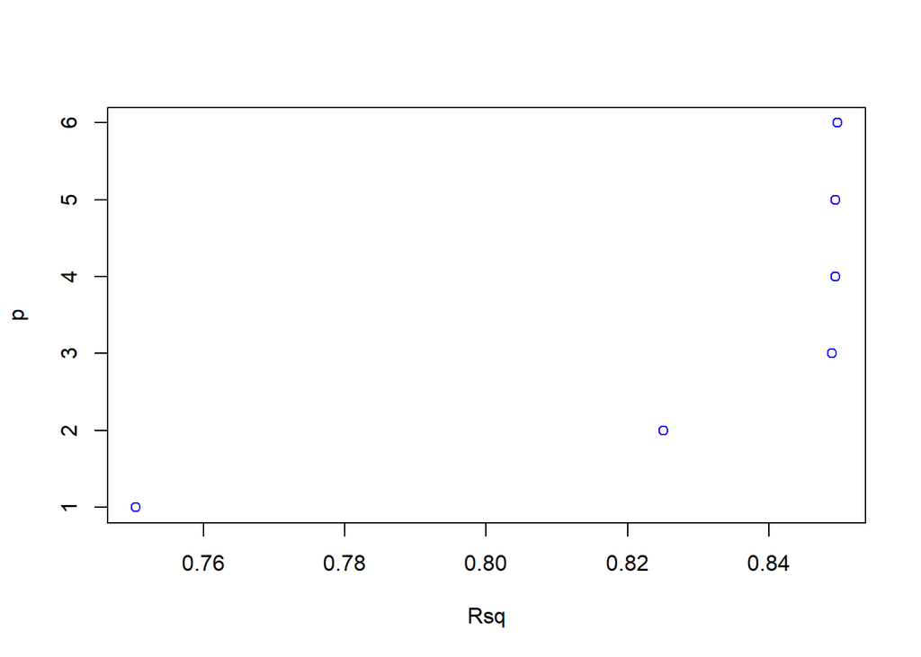

```r
 p<-c(1,2,3,4,5,6)
 Rsq<-c(0.7504,0.8251,0.8489,0.8494,0.8494,0.8497)
 plot(Rsq,p,col='blue')
```

# Step 18

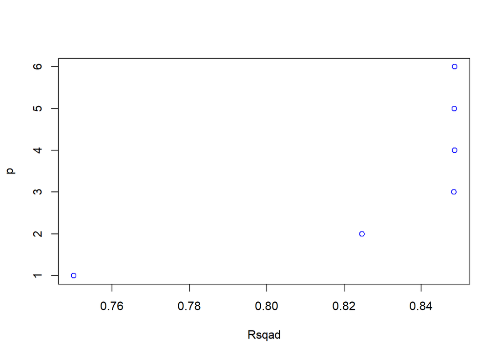

```r
 Rsqad<-c(0.7501,0.8247,0.8484,0.8486,0.8485,0.8486)
 plot(Rsqad,p,col='blue')
```

# Step 19

```r
 AIC(model1)
```

```
## [1] 12508.81
```

```r
 AIC(model2)
```

```
## [1] 12215.05
```

```r
 AIC(model3)
```

```
## [1] 12095.65
```

```r
 AIC(model4)
```

```
## [1] 12095.05
```

```r
 AIC(model5)
```

```
## [1] 12096.99
```

```r
 AIC(model6)
```

```
## [1] 12097.14
```

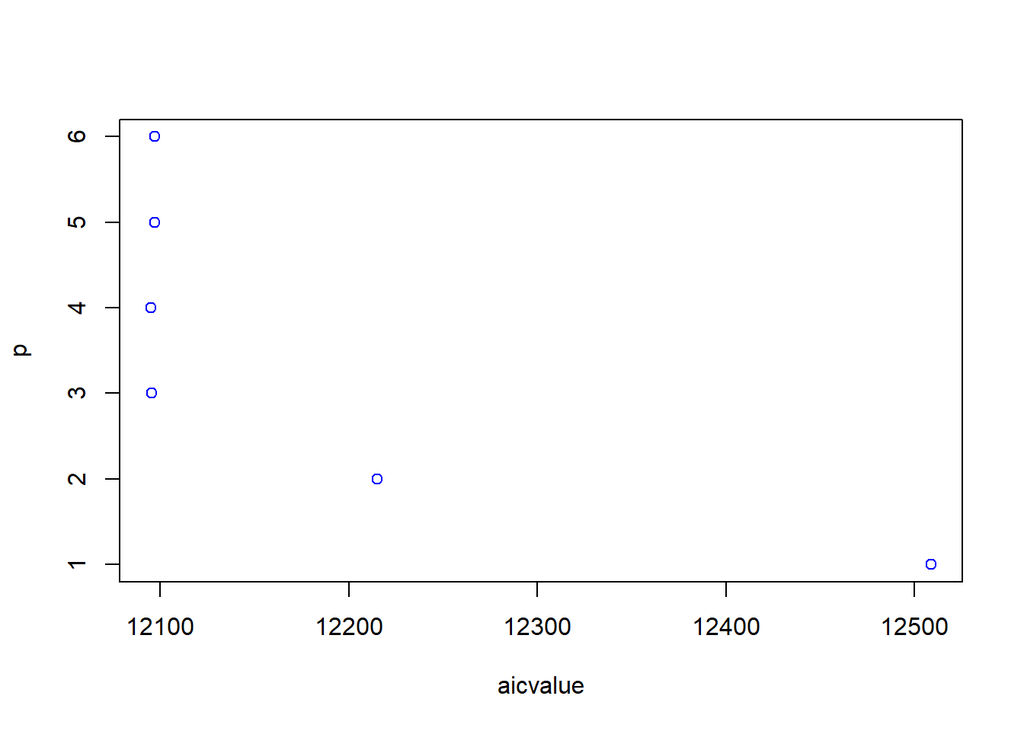

```r
 aicvalue<- c(12508.81,12215.05,12095.65,12095.05,12096.99,12097.14)
 plot(aicvalue,p,col='blue')
```

# Step 20

Based on above plots, model with 4 parameters gives the best predictive ability Hence, we would select speed_ground,aircraft, pitch and height

# Step 21

```r
 model<-lm(distance~.,data=FAA_dist2)
 m<-lm(distance~1,data=FAA_dist2)
 require(MASS)
 result<-stepAIC(m,direction="forward",scope=list(lower=m,upper=model))
```

```
## Start:  AIC=11299.8
## distance ~ 1
##
##                Df Sum of Sq       RSS   AIC
## + speed_ground  1 500382567 166457762 10148
## + aircraft      1  37818390 629021939 11253
## + height        1   6590108 660250221 11294
## + pitch         1   5050617 661789712 11296
## + duration      1   1745252 665095078 11300
## <none>                      666840329 11300
## + no_pasg       1    210253 666630076 11302
##
## Step:  AIC=10148.53
## distance ~ speed_ground
##
##            Df Sum of Sq       RSS     AIC
## + aircraft  1  49848656 116609106  9854.8
## + height    1  14916377 151541385 10072.5
## + pitch     1   9765095 156692668 10100.3
## <none>                  166457762 10148.5
## + no_pasg   1    207528 166250234 10149.5
## + duration  1     60223 166397539 10150.2
##
## Step:  AIC=9854.77
## distance ~ speed_ground + aircraft
##
##            Df Sum of Sq       RSS    AIC
## + height    1  15848830 100760276 9735.4
## + pitch     1    455453 116153653 9853.5
## <none>                  116609106 9854.8
## + no_pasg   1     87171 116521935 9856.1
## + duration  1      8447 116600659 9856.7
##
## Step:  AIC=9735.37
## distance ~ speed_ground + aircraft + height
##
##            Df Sum of Sq       RSS    AIC
## + pitch     1    315259 100445017 9734.8
## <none>                  100760276 9735.4
## + no_pasg   1    232003 100528273 9735.5
## + duration  1      3999 100756277 9737.3
##
## Step:  AIC=9734.77
## distance ~ speed_ground + aircraft + height + pitch
##
##            Df Sum of Sq       RSS    AIC
## <none>                  100445017 9734.8
## + no_pasg   1    225608 100219409 9734.9
## + duration  1      6709 100438308 9736.7
```

```r
 result$anova
```

| Step | Df | Deviance | Resid. Df | Resid. Dev | AIC |
| --- | --- | --- | --- | --- | --- |
|  | NA | NA | 830 | 666840329 | 11299.803 |
| + speed_ground | 1 | 500382566.8 | 829 | 166457762 | 10148.534 |
| + aircraft | 1 | 49848656.1 | 828 | 116609106 | 9854.769 |
| + height | 1 | 15848830.0 | 827 | 100760276 | 9735.374 |
| + pitch | 1 | 315259.4 | 826 | 100445017 | 9734.770 |

The model recieved from StepAIC function also gives the same 4 parameters evaluated in step 19

# Conclusion:

Looking at the above model results, we will take 4 variables(speed_ground,aircraft, pitch and height) into consideration for predicting the landing distance